# Practical Machine Learning Assignment

Alex Hannon

25 October 2015

# Executive Summary

# Preprocessing/Exploratory data analysis

Set the working directory and load in the data. Also turned off warnings, as at a later point during the model development stage a number of warnings occur for the Naive Bayes model.

```r
setwd("/home/alex/Documents/PracticalMachineLearningAssignment")
set.seed(666)
#Load the training data
trainingData <- read.csv("pml-training.csv", header = TRUE, na.strings = c("NA", ""))
#Load the testing data
testingData <- read.csv("pml-testing.csv", header = TRUE, na.strings = c("NA", ""))
options(warn=-1)
```

The dataset contains a large number of variables with little to no data in them, containing NA instead. Here we remove variables with such NA values, and proceed to drop a number of variables relating to the metadata and time. After performing this on the training set we do the same to the test set, which we will refer to as the validation set, from here on, to prevent confusion with our own test set we will create.

```r
# look at the number of observations and variables
dim(trainingData)
```

```
## [1] 19622   160
```

```r
dim(testingData)
```

```
## [1]  20 160
```

```r
# remove large number of blank columns
trainingDataNNA <- trainingData[ , colSums(is.na(trainingData)) == 0]
dim(trainingDataNNA)
```

```
## [1] 19622    60
```

```r
# disregard metadata and time related variables
trainingDataNNAIrrelevant <- trainingDataNNA[,-c(1:8)]
dim(trainingDataNNAIrrelevant)
```

```
## [1] 19622    52
```

```r
# do the same to the test set
validationSet <- testingData[, names(trainingDataNNAIrrelevant[,-52])]
dim(validationSet)
```

```
## [1] 20 51
```

Next we load the necessary libraries for the rest of the analysis (note some of the packages might not be used, ended up cutting out quite a few plots and whatnot that required them and don’t have time to verify which ones I’m using, certain dependencies exist between one or two of the packages and I don’t have time to verify which ones are dependent on which. I’m using a proxy version of R that’s very fickle about dependencies. )

```r
library(caret)
```

```r
library(ISLR)
library(ggplot2)
library(corrplot)
library(HEAT)
library(reshape2)
```

Next we proceed to create a correlation matrix, first changing values to numeric, observing how many variables are in our new dataset, before emitting the classe variable from observation.

```r
#correlation matrix
corMatrixPrep <- cor(na.omit(trainingDataNNAIrrelevant[sapply(trainingDataNNAIrrelevant, is.numeric)]))
dim(corMatrixPrep)
```

```
## [1] 51 51
```

```r
corMat <- cor(corMatrixPrep[, -51])
```

We create a significance test function to roughly highlight variables that have a low level of correlation, suitable for analysis.

```r
cor.mtest <- function(mat, conf.level = 0.95) {
    mat <- as.matrix(mat)
    n <- ncol(mat)
    p.mat <- lowCI.mat <- uppCI.mat <- matrix(NA, n, n)
    diag(p.mat) <- 0
    diag(lowCI.mat) <- diag(uppCI.mat) <- 1
    for (i in 1:(n - 1)) {
        for (j in (i + 1):n) {
            tmp <- cor.test(mat[, i], mat[, j], conf.level = conf.level)
            p.mat[i, j] <- p.mat[j, i] <- tmp$p.value
            lowCI.mat[i, j] <- lowCI.mat[j, i] <- tmp$conf.int[1]
            uppCI.mat[i, j] <- uppCI.mat[j, i] <- tmp$conf.int[2]
        }
    }
    return(list(p.mat, lowCI.mat, uppCI.mat))
}
```

Next we create our plot, inputing our preferred significance levels, which will highlight with X suitable variables for analysis. This only serves to highlight said variables and as a rough guideline as to were clusters of good variables are located.

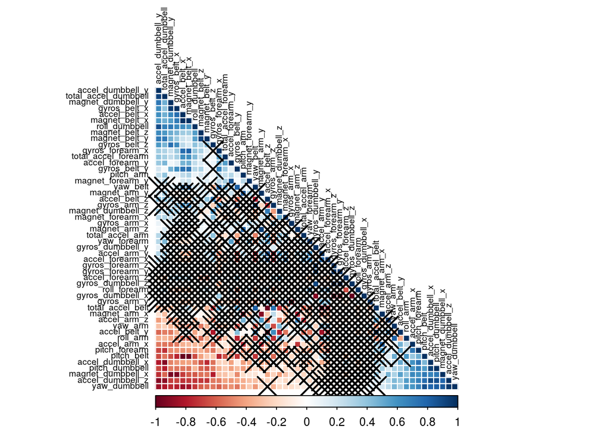

```r
res1<-cor.mtest(corMat, 0.95)
res2<-cor.mtest(corMat, 0.99)
corrplot(corMat, p.mat = res1[[1]], sig.level = 0.2, order = "FPC", method = "color",
         type = "lower", tl.cex = .6, tl.col = rgb(0, 0, 0))
```

Finally we implement a cutoff point, of 90%, where, if the correlation is over said point, it will be removed from analysis. Finally we observe the number of variables and observations in our test and validation sets

```r
noCor = findCorrelation(corMatrixPrep, cutoff = .90, verbose = TRUE)
```

```
## Compare row 9  and column  8 with corr  0.933
##   Means:  0.256 vs 0.164 so flagging column 9
## Compare row 8  and column  3 with corr  0.928
##   Means:  0.233 vs 0.161 so flagging column 8
## Compare row 7  and column  1 with corr  0.966
##   Means:  0.245 vs 0.157 so flagging column 7
## Compare row 18  and column  17 with corr  0.918
##   Means:  0.091 vs 0.158 so flagging column 17
## Compare row 45  and column  30 with corr  0.914
##   Means:  0.101 vs 0.161 so flagging column 30
## Compare row 45  and column  32 with corr  0.933
##   Means:  0.083 vs 0.164 so flagging column 32
## All correlations <= 0.9
```

```r
finalTrainingSet <- trainingDataNNAIrrelevant[,-noCor]
finalValidationSet <- validationSet[, -noCor]

#check number of dimensions in training set
dim(finalTrainingSet)
```

```
## [1] 19622    46
```

```r
#check number of dimensions in validation set
dim(finalValidationSet)
```

```
## [1] 20 45
```

# Model Creation

```r
#Create a new test set for work on
inTrain<-createDataPartition(y=finalTrainingSet$classe, p=0.75,list=FALSE)
training<-finalTrainingSet[inTrain,]
test<-finalTrainingSet[-inTrain,]
#check dimensions of test set and number of observations
dim(test)
```

```
## [1] 4904   46
```

```r
#check dimensions of training set and number of observations
dim(training)
```

```
## [1] 14718    46
```

We then need to perform principle component analysis (admittedly should have done this prior to removing the correlated variables but once more time is an issue). We use the PCA transformations on all three datasets, the training, test and validation sets in order to create allow models to run on all three

```r
PCATraining <- preProcess(training[, -45], method = "pca", thresh = 0.99)
PCATrained <- predict(PCATraining, training[, -45])
PCATEST <- predict(PCATraining, test[, -45])
PCAValidation <- predict(PCATraining, finalValidationSet[, -45])
```

## Random Forest

For our first model we will try the typically high creating a random forest model, using five fold cross-validation

```r
randomForestModel <- train(classe ~ ., method = "rf", data = PCATrained,
                           trControl = trainControl(method = "cv", number = 5),
                           importance = TRUE)
```

We observe the most significant variables in model creation, notice however that they have been transformed into principle components now. For random forest the significance level is based on the mean decrease in accuracy if the variable were removed, hence these principle components are ranked accordingly.

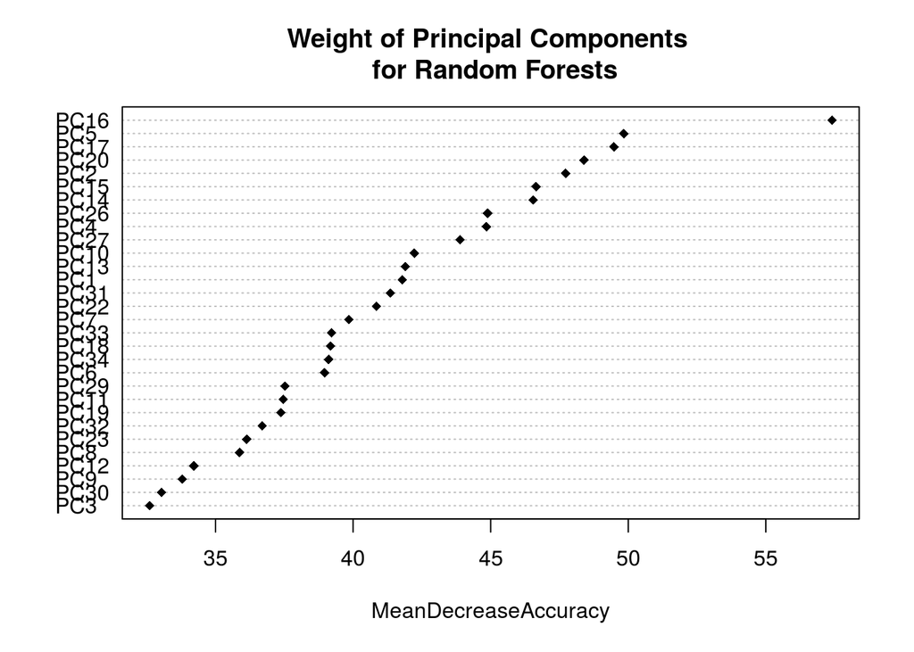

```r
varImpPlot(randomForestModel$finalModel, sort = TRUE, type = 1, pch = 18, col = 1, cex = 1,
           main = "Weight of Principal Components \n for Random Forests")
```

```r
SVMModel <- train(classe ~ ., data=PCATrained, model="svm", trControl = trainControl(method = "cv", number = 5))
```

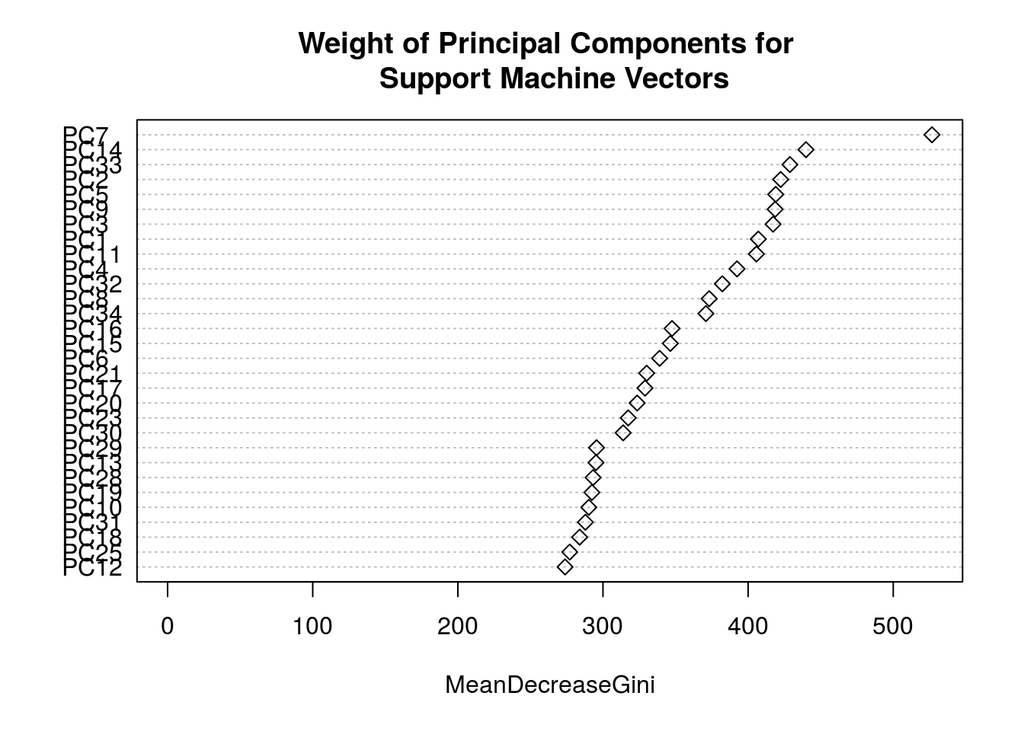

```r
#uses ROC to calculate significance
varImpPlot(SVMModel$finalModel, sort = TRUE,  pch = 5, col = 1, cex = 1,
           main = "Weight of Principal Components for \n Support Machine Vectors")
```

## Naive Bayes

Finally we create a Naive Bayes model, using five fold cross validation once more.

```r
naiveModel = train(classe ~., data=PCATrained, method="nb", trControl = trainControl(method = "cv", number = 5))
```

# Model Selection

In order to select our best model lets sequentially review our three models, before finally comparing all three.

## Random Forest

Here we create our prediction for the test set we created earlier. Then in order to assess our accuracy and out of sample error rate we perform a simple correlation matrix.

```r
predictedValuesRF <- predict(randomForestModel, PCATEST)
confusionMatrix(predictedValuesRF, PCATEST$classe)
```

```
## Confusion Matrix and Statistics
##
##           Reference
## Prediction    A    B    C    D    E
##          A 1393   16    1    1    0
##          B    1  924    7    0    1
##          C    0    7  843   37    7
##          D    1    1    4  763    5
##          E    0    1    0    3  888
##
## Overall Statistics
##
##                Accuracy : 0.981
##                  95% CI : (0.9768, 0.9847)
##     No Information Rate : 0.2845
##     P-Value [Acc > NIR] : < 2.2e-16
##
##                   Kappa : 0.976
##  Mcnemar's Test P-Value : NA
##
## Statistics by Class:
##
##                      Class: A Class: B Class: C Class: D Class: E
## Sensitivity            0.9986   0.9737   0.9860   0.9490   0.9856
## Specificity            0.9949   0.9977   0.9874   0.9973   0.9990
## Pos Pred Value         0.9872   0.9904   0.9430   0.9858   0.9955
## Neg Pred Value         0.9994   0.9937   0.9970   0.9901   0.9968
## Prevalence             0.2845   0.1935   0.1743   0.1639   0.1837
## Detection Rate         0.2841   0.1884   0.1719   0.1556   0.1811
## Detection Prevalence   0.2877   0.1903   0.1823   0.1578   0.1819
## Balanced Accuracy      0.9967   0.9857   0.9867   0.9732   0.9923
```

## Support Vector Machine

Again we create our prediction for the test set we created earlier. Then in order to assess our accuracy and out of sample error rate we perform a simple correlation matrix.

```r
svmPredictions <- predict(SVMModel, PCATEST)
confusionMatrix(svmPredictions, PCATEST$classe)
```

```
## Confusion Matrix and Statistics
##
##           Reference
## Prediction    A    B    C    D    E
##          A 1393   17    1    1    0
##          B    1  924    7    0    1
##          C    0    7  843   37    7
##          D    1    0    4  761    5
##          E    0    1    0    5  888
##
## Overall Statistics
##
##                Accuracy : 0.9806
##                  95% CI : (0.9764, 0.9843)
##     No Information Rate : 0.2845
##     P-Value [Acc > NIR] : < 2.2e-16
##
##                   Kappa : 0.9755
##  Mcnemar's Test P-Value : NA
##
## Statistics by Class:
##
##                      Class: A Class: B Class: C Class: D Class: E
## Sensitivity            0.9986   0.9737   0.9860   0.9465   0.9856
## Specificity            0.9946   0.9977   0.9874   0.9976   0.9985
## Pos Pred Value         0.9865   0.9904   0.9430   0.9870   0.9933
## Neg Pred Value         0.9994   0.9937   0.9970   0.9896   0.9968
## Prevalence             0.2845   0.1935   0.1743   0.1639   0.1837
## Detection Rate         0.2841   0.1884   0.1719   0.1552   0.1811
## Detection Prevalence   0.2879   0.1903   0.1823   0.1572   0.1823
## Balanced Accuracy      0.9966   0.9857   0.9867   0.9720   0.9920
```

## Naive Bayes

Finally we create the predictions for the final model for out test set. Then, once more, in order to assess our accuracy and out of sample error rate we perform a simple correlation matrix.

```r
naivePredictions <- predict(naiveModel, PCATEST)
confusionMatrix(naivePredictions, PCATEST$classe)
```

```
## Confusion Matrix and Statistics
##
##           Reference
## Prediction    A    B    C    D    E
##          A 1053   96   55   46   21
##          B   91  594   70   17  134
##          C  111  131  643  126   68
##          D  100   29   50  530   63
##          E   40   99   37   85  615
##
## Overall Statistics
##
##                Accuracy : 0.7004
##                  95% CI : (0.6874, 0.7132)
##     No Information Rate : 0.2845
##     P-Value [Acc > NIR] : < 2.2e-16
##
##                   Kappa : 0.6225
##  Mcnemar's Test P-Value : < 2.2e-16
##
## Statistics by Class:
##
##                      Class: A Class: B Class: C Class: D Class: E
## Sensitivity            0.7548   0.6259   0.7520   0.6592   0.6826
## Specificity            0.9379   0.9211   0.8923   0.9410   0.9348
## Pos Pred Value         0.8285   0.6556   0.5959   0.6865   0.7021
## Neg Pred Value         0.9059   0.9112   0.9446   0.9337   0.9290
## Prevalence             0.2845   0.1935   0.1743   0.1639   0.1837
## Detection Rate         0.2147   0.1211   0.1311   0.1081   0.1254
## Detection Prevalence   0.2592   0.1847   0.2200   0.1574   0.1786
## Balanced Accuracy      0.8464   0.7735   0.8222   0.8001   0.8087
```

As we can see the naive bayes model is by far the weakest of the three models, with an accuracy of only 70.04% and as a result 29.96% of an out of sample error rate.

## Review the three models

Finally we create a mask to hold our three different models data in, results, from which we can compare and contrast them

```r
results <- resamples(list(RF=randomForestModel, SVM=SVMModel, NB=naiveModel))
summary(results)
```

```
##
## Call:
## summary.resamples(object = results)
##
## Models: RF, SVM, NB
## Number of resamples: 5
##
## Accuracy
##       Min. 1st Qu. Median   Mean 3rd Qu.   Max. NA's
## RF  0.9725  0.9742 0.9755 0.9760  0.9776 0.9803    0
## SVM 0.9728  0.9735 0.9742 0.9747  0.9765 0.9765    0
## NB  0.6716  0.6833 0.6854 0.6838  0.6871 0.6916    0
##
## Kappa
##       Min. 1st Qu. Median   Mean 3rd Qu.   Max. NA's
## RF  0.9652  0.9673 0.9690 0.9696  0.9716 0.9751    0
## SVM 0.9656  0.9665 0.9673 0.9680  0.9703 0.9703    0
## NB  0.5874  0.6011 0.6037 0.6017  0.6052 0.6112    0
```

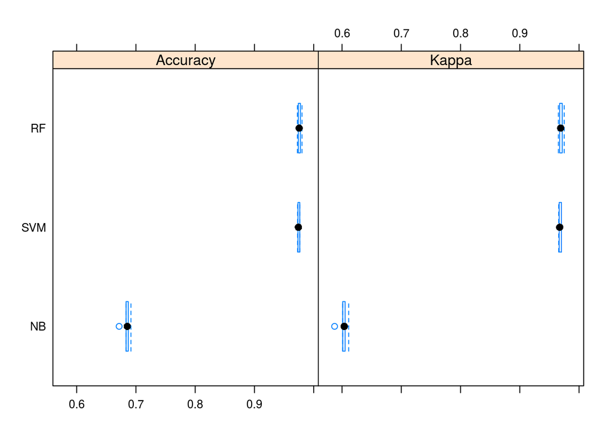

```r
bwplot(results)
```

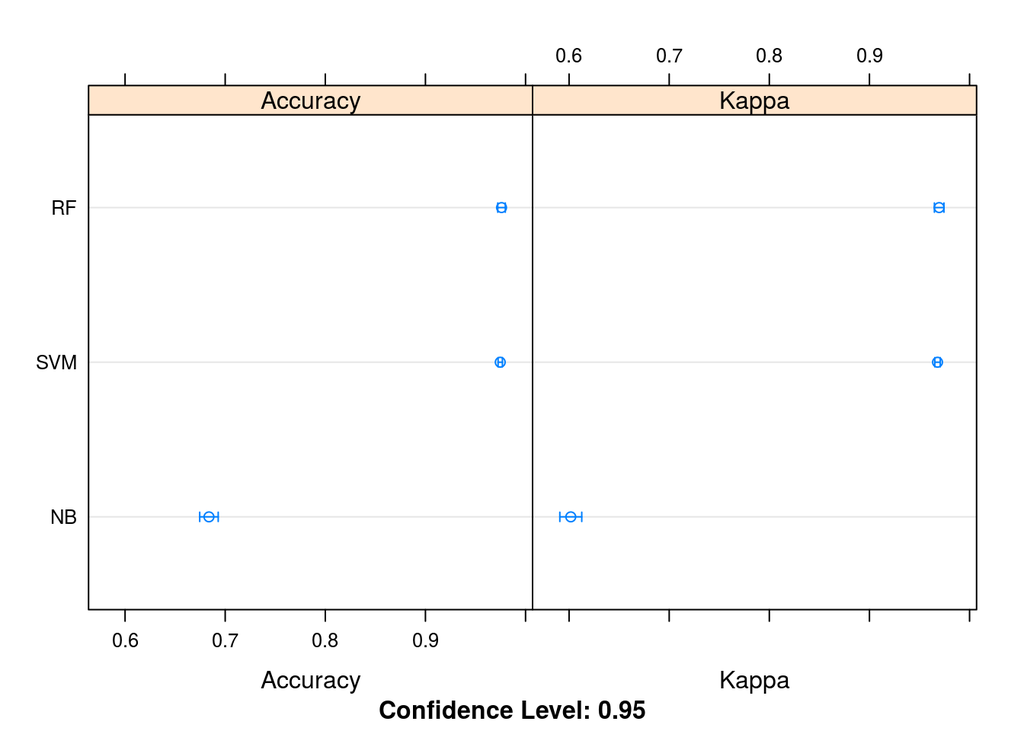

```r
dotplot(results)
```

```r
answers1 <- predict(randomForestModel, PCAValidation)
answers1
```

```
##  [1] B A B A A E D B A A B C B A E E A B B B
## Levels: A B C D E
```

```r
answers2 <- predict(SVMModel, PCAValidation)
answers2
```

```
##  [1] B A B A A E D B A A B C B A E E A B B B
## Levels: A B C D E
```

```r
answers3 <- predict(naiveModel, PCAValidation)
answers3
```

```
##  [1] D A A C A D D D A A A C E A E D A E B B
## Levels: A B C D E
```